# Iris Classification

Katie M Brown

April 12, 2019

## Question

What species of flower is the iris, based off of it’s physical features?

## Methodology

I used the k-nearest neighbor classification algorithm to group the observations by features. The steps I used are as follows: standardize the data, split data into train and test sets, build a knn model, use the model with k set to some value to make an initial prediction, check misclassification rate. Then, I’ll choose the best k value by plotting the misclassification rates and finding where it is minimized.

## Libraries

I used the following libraries for this project: ISLR (to get iris data), caTools (for splitting data), ggplot2 (for visualizations), class (for classification)

```r
library(ISLR)
library(caTools)
library(ggplot2)
library(class)
```

## Getting, Cleaning and standardizing the data

I loaded the ISLR package so that I could use the iris dataset. I did some initial reconnaissance here:

```r
str(iris)
```

```
## 'data.frame':    150 obs. of  5 variables:
##  $ Sepal.Length: num  5.1 4.9 4.7 4.6 5 5.4 4.6 5 4.4 4.9 ...
##  $ Sepal.Width : num  3.5 3 3.2 3.1 3.6 3.9 3.4 3.4 2.9 3.1 ...
##  $ Petal.Length: num  1.4 1.4 1.3 1.5 1.4 1.7 1.4 1.5 1.4 1.5 ...
##  $ Petal.Width : num  0.2 0.2 0.2 0.2 0.2 0.4 0.3 0.2 0.2 0.1 ...
##  $ Species     : Factor w/ 3 levels "setosa","versicolor",..: 1 1 1 1 1 1 1 1 1 1 ...
```

```r
summary(iris)
```

```
##   Sepal.Length    Sepal.Width     Petal.Length    Petal.Width
##  Min.   :4.300   Min.   :2.000   Min.   :1.000   Min.   :0.100
##  1st Qu.:5.100   1st Qu.:2.800   1st Qu.:1.600   1st Qu.:0.300
##  Median :5.800   Median :3.000   Median :4.350   Median :1.300
##  Mean   :5.843   Mean   :3.057   Mean   :3.758   Mean   :1.199
##  3rd Qu.:6.400   3rd Qu.:3.300   3rd Qu.:5.100   3rd Qu.:1.800
##  Max.   :7.900   Max.   :4.400   Max.   :6.900   Max.   :2.500
##        Species
##  setosa    :50
##  versicolor:50
##  virginica :50
##
##
##
```

```r
any(is.na(iris))
```

```
## [1] FALSE
```

From here, I saw that the label data, Species, was a factor with 3 levels. I also noted that there are no missing values to deal with. I then standardized the data:

```r
species <- iris$Species
standard.iris <- as.data.frame(scale(iris[,-5]))
```

## Split the data

After standardizing the data, I split it into training and testing data sets. I did this using the caTools package and the sample.split function:

```r
set.seed(101)
sample <- sample.split(standard.iris$Sepal.Length,SplitRatio=.8)

train.iris <- subset(standard.iris,sample == TRUE)
train.species <- species[sample == TRUE]

test.iris <- subset(standard.iris,sample == FALSE)
test.species <- species[sample == FALSE]
```

## KNN Classification

Now I will run the KNN algorithm with k set equal to 12. This is an initial k value that will most likely eventually change but we have to start somewhere. I chose this k value because it is the closest integer to the square root of 150. After running the model, I checked the misclassification error.

```r
predicted.species <- knn(train.iris, test.iris, train.species, k = 12)
head(predicted.species)
```

```
## [1] setosa setosa setosa setosa setosa setosa
## Levels: setosa versicolor virginica
```

```r
misclassification.error <- mean(test.species != predicted.species)
```

## Choosing K where error rate is minimized

At this point, I looped through each possible k value and test the misclassification error to find the ideal k.

```r
predicted.species <- NULL
error.rate <- NULL

for(i in 1:12) {
      set.seed(101)
      predicted.species<- knn(train.iris, test.iris, train.species, k = i)
      error.rate[i] <- mean(test.species != predicted.species)
}
```

Then I visualized the error rates vs. their associated k value:

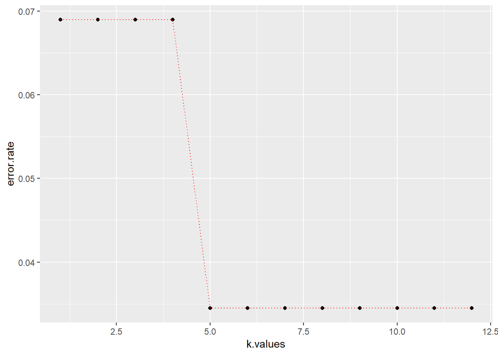

```r
k.values <- 1:12
error.df <- data.frame(error.rate, k.values)

ggplot(error.df, aes(k.values, error.rate)) + geom_point() + geom_line(lty='dotted', col = 'red')
```

In this example, the error rate is minimized first when k = 5. The predicted species along with the error rate:

```r
predicted.species <- knn(train.iris, test.iris, train.species, k = 5)
print(predicted.species)
```

```
##  [1] setosa     setosa     setosa     setosa     setosa     setosa
##  [7] setosa     setosa     setosa     versicolor versicolor versicolor
## [13] versicolor versicolor versicolor versicolor versicolor virginica
## [19] virginica  virginica  versicolor virginica  virginica  virginica
## [25] virginica  virginica  virginica  virginica  virginica
## Levels: setosa versicolor virginica
```

```r
misclassification.error <- mean(test.species != predicted.species)
print(misclassification.error)
```

```
## [1] 0.03448276
```